# Great Lakes Ice Cover: Final Report

Michael Okanta & Oliver Yawlui

2024-11-20

## Introduction

The goal of this project is to examine long-term trends and potential systemic changes in Great Lakes ice cover over the past 50 years. The dataset consists of daily ice cover percentages for each year, capturing seasonal fluctuations and annual variations in ice coverage across the lakes. To provide a robust and comprehensive analysis, a dual approach involving imputation was utilized to handle missing values and AUC (Area Under the Curve) calculations to quantify seasonal ice cover for each year.

## Methods

### Data

The analysis of the Great Lakes ice cover data began with an exploration of the dataset’s structure, where each column represented a specific year and each row corresponded to a day of the year in day-month format. This setup gave insights into ice cover patterns on a daily basis across multiple decades. However, significant gaps were quickly noticed in the dataset. Records existed from early November through early June, but no data was collected between June 6 and November 9. This gap made sense because ice typically melts during the summer months, so we left these periods blank to reflect the natural seasonal cycle. Within the recorded winter season, additional gaps were observed, especially at the beginning and end of the ice season, possibly due to variations in data collection or natural fluctuations as winter transitions in and out.

### Handling NAs

Handling missing values (NAs) in the Great Ice Lakes dataset required addressing several challenges inherent in the data structure and its physical context. The dataset, consisting of daily ice cover percentages over multiple years, included missing values at the beginning, middle, or end of some years. Additionally, the presence of February 29 in leap years created inconsistencies, as not all years contained data for this date.

To address the February 29 issue, standardization was implemented by replacing February 29 values in non-leap years with 0% ice cover, as these values were not applicable. This choice reflects the physical impossibility of ice cover data for a day that does not exist in those years. An initial attempt was made to handle missing values using direct interpolation. However, this approach led to issues, particularly with leading NAs (missing values at the beginning of a year). In such cases, direct interpolation filled all preceding NAs with the first observed value, leading to unrealistic assumptions. For instance, if the first recorded ice cover value in a year was 17.5%, all preceding NAs were filled with 17.5%, implying that the ice cover was already substantial at the start of the year. This assumption was problematic, as ice cover typically begins at a somewhat small percentage and gradually increases. Such an approach failed to account for the natural progression of ice formation.

To resolve this issue, a more realistic method was developed for handling leading NAs. When the first recorded value in a year was missing, the values were filled by gradually increasing from 5% of the first observed value in that year to the observed value itself. For example, if the first recorded value was 17.5%, the preceding NAs were filled with a sequence starting at 0.875 (5% of 17.5%) and increasing linearly to 17.5%. This approach better represented the gradual buildup of ice cover over time. Trailing NAs (missing values at the end of a year) were addressed similarly. Instead of assuming constant ice cover at the last observed value, trailing NAs were filled by gradually decreasing to 5% of the last recorded value. For instance, if the final observed value was 20%, trailing NAs were filled with values linearly decreasing from 20% to 5% of 20%. This method simulated the natural melting of ice as temperatures rose at the end of the season, ensuring a realistic representation of ice cover dynamics.

For internal gaps (missing values between two observed points within a year), linear interpolation was applied. This method estimated missing values based on a straight-line relationship between the two nearest observed values, ensuring smooth transitions and maintaining the dataset’s temporal continuity. The `na.approx` function from the `zoo` package was used for this purpose, providing an effective solution for internal gaps.

To implement these methods comprehensively, a single function was developed that processed each year of data individually. Leading NAs, trailing NAs, and internal gaps were handled sequentially within this function, ensuring that missing values were addressed holistically and consistently. This approach maintained the dataset’s alignment with the physical processes governing ice cover.

Once missing values were handled, the dataset was reshaped into a long format to facilitate further analysis. This involved creating a date variable derived from the day-month combination and the year, enabling calculations of summary statistics such as mean, median, and standard deviation of ice cover for each month and year. Additionally, the area under the curve (AUC) was computed for each year using the `auc` function from the `MESS` package. The AUC provided a comprehensive measure of the total extent and duration of ice cover for a given year, capturing long-term trends and anomalies.

This approach ensured that missing values were handled realistically, avoiding the pitfalls of direct interpolation while preserving the temporal and physical integrity of the data. The reconstructed dataset was thus made suitable for subsequent statistical analyses, supporting deeper insights into ice cover trends across the Great Lakes.

To explore the processed dataset, several visualization techniques were employed: Heatmap of Ice Cover Across Days and Years: This visualization provided a detailed representation of daily ice cover patterns over multiple years, highlighting periods of maximum and minimum coverage. Time Series of Annual AUC Values: The area under the curve (AUC) was calculated for each year to summarize the total extent and duration of ice cover. A line plot of annual AUC values allowed for the identification of temporal trends and anomalies over the study period. These visualizations not only illustrated the trends in the data but also validated the effectiveness of the imputation methods by ensuring that reconstructed patterns were consistent with known seasonal variations.

An alternative approach was considered to evaluate the overall trend in ice cover over time. This involved removing all rows with missing values and fitting a linear model using AUC as the response variable and year as the predictor. The cleaned dataset was used to calculate annual AUC values, and both a linear and polynomial regression model, $(\text{AUC} \sim \text{year})$ and $(\text{AUC} \sim \text{poly(year, 2)}$ were fitted to these data. The performance of these models were assessed using the Akaike Information Criterion (AIC) and the Bayesian Information Criterion (BIC). The results of these models were compared to the original approach that incorporated the imputed missing values. The AIC and BIC scores for both models for both approaches differed by less than 2, indicating that the two approaches performed similarly. However, the original approach, which handled missing values through a combination of gradual adjustments and interpolation, was retained. This decision was based on its ability to better capture the physical dynamics of ice cover progression and recession, offering a more realistic representation of seasonal trends.

### Statistical Analysis

To assess long-term trends in ice cover, an initial view of the trend in the annual AUC values was considered. This informed the polynomial regression model (because the trend showed a somewhat non-linear trend). The Mann-Kendall test was also employed (after the normality assumptions failed for the polynomial model). This non-parametric test is particularly suited for detecting monotonic trends in time-series data without requiring the data to follow a specific distribution. The Mann-Kendall test was applied to the annual AUC values to determine whether a significant upward or downward trend existed in the cumulative ice cover over the study period. The results of the Mann-Kendall test indicated whether the observed changes in AUC values were statistically significant or could be attributed to random variability. This complemented the polynomial regression analysis by providing a robust, distribution-free measure of trend significance.

### Software

The following software resources were used to conduct the described analysis:

- R Core Team. AUC calculation with PKNCA. Retrieved from https://cran.r-project.org/web/packages/PKNCA/vignettes/v05-auc-calculation-with-PKNCA.html
- Pacific Northwest National Laboratory. Designing for trend analysis: Mann-Kendall test. Retrieved from https://vsp.pnnl.gov/help/vsample/design_trend_mann_kendall.htm
- McLeod, A. I. Kendall: Kendall rank correlation and Mann-Kendall trend test. CRAN. Retrieved from https://cran.r-project.org/web/packages/Kendall/index.html

## Results

### EDA

The exploratory data analysis (EDA) aids in identifying patterns and trends before conducting inferential analysis. Table 1 summarizes key descriptive statistics of ice cover across months for each year in the dataset. It provides an overview of the mean, median, maximum, minimum, and standard deviation of ice cover percentages, highlighting variability in ice conditions over time.

Table 1: Summary statistics of percentage ice cover

| year | month | mean_ice_cover | median_ice_cover | max_ice_cover | min_ice_cover | sd_ice_cover |
| --- | --- | --- | --- | --- | --- | --- |
| 1973 | 1 | 18.8225806 | 20.0000000 | 25.6000000 | 10.7000000 | 4.6587344 |
| 1973 | 2 | 36.5071429 | 36.8500000 | 60.6000000 | 13.0000000 | 15.7751076 |
| 1973 | 3 | 21.7419355 | 16.7000000 | 55.7000000 | 3.1000000 | 17.1301639 |
| 1973 | 4 | 1.8508333 | 1.7841250 | 2.9000000 | 1.3020000 | 0.4179067 |
| 1973 | 5 | 0.7700000 | 0.7700000 | 1.2687500 | 0.2712500 | 0.3023130 |
| 1973 | 6 | 0.1715000 | 0.1715000 | 0.2380000 | 0.1050000 | 0.0525729 |
| 1973 | 11 | 3.0187500 | 3.0187500 | 5.5125000 | 0.5250000 | 1.5473312 |
| 1973 | 12 | 8.8231855 | 9.0037500 | 11.9000000 | 5.7618750 | 1.6603331 |
| 1974 | 1 | 23.0258065 | 22.2000000 | 34.4000000 | 9.7000000 | 7.0665394 |
| 1974 | 2 | 45.8285714 | 53.9000000 | 58.7000000 | 18.3000000 | 13.7692050 |
| 1974 | 3 | 37.2161290 | 36.7000000 | 51.9000000 | 30.0000000 | 4.4658032 |
| 1974 | 4 | 12.7000000 | 10.9000000 | 30.4000000 | 3.0000000 | 8.1676823 |
| 1974 | 5 | 0.9473672 | 0.9132353 | 2.6000000 | 0.2845588 | 0.4750503 |
| 1974 | 6 | 0.1588235 | 0.1588235 | 0.2426471 | 0.0750000 | 0.0662683 |
| 1974 | 11 | 1.2995098 | 1.2995098 | 2.3240196 | 0.2750000 | 0.6356916 |
| 1974 | 12 | 3.9632353 | 3.9632353 | 5.5000000 | 2.4264706 | 0.9314967 |
| 1975 | 1 | 11.7603652 | 10.9000000 | 22.4000000 | 1.5713208 | 8.1387083 |
| 1975 | 2 | 32.6785714 | 30.1000000 | 50.2000000 | 22.6000000 | 8.8445152 |
| 1975 | 3 | 17.7548387 | 16.4000000 | 27.5000000 | 8.7000000 | 6.9169762 |
| 1975 | 4 | 8.6000000 | 6.3500000 | 18.2000000 | 3.4571429 | 5.2373819 |
| 1975 | 5 | 2.0095238 | 2.0095238 | 3.3666667 | 0.6523810 | 0.8226205 |
| 1975 | 6 | 0.3809524 | 0.3809524 | 0.5619048 | 0.2000000 | 0.1430554 |
| 1975 | 11 | 0.3667925 | 0.3667925 | 0.6535849 | 0.0800000 | 0.1779500 |
| 1975 | 12 | 1.1124528 | 1.1124528 | 1.5426415 | 0.6822642 | 0.2607552 |
| 1976 | 1 | 24.4741935 | 26.8000000 | 37.7000000 | 9.2000000 | 9.3626196 |
| 1976 | 2 | 32.7241379 | 35.5000000 | 39.9000000 | 22.2000000 | 5.8936803 |
| 1976 | 3 | 24.4516129 | 26.9000000 | 32.1000000 | 10.5000000 | 6.9958021 |
| 1976 | 4 | 4.4698732 | 4.2500000 | 10.1000000 | 1.1902174 | 3.0987487 |
| 1976 | 5 | 0.6945652 | 0.6945652 | 1.1592391 | 0.2298913 | 0.2816581 |
| 1976 | 6 | 0.1369565 | 0.1369565 | 0.1989130 | 0.0750000 | 0.0489809 |

[output cut: 386 more lines]

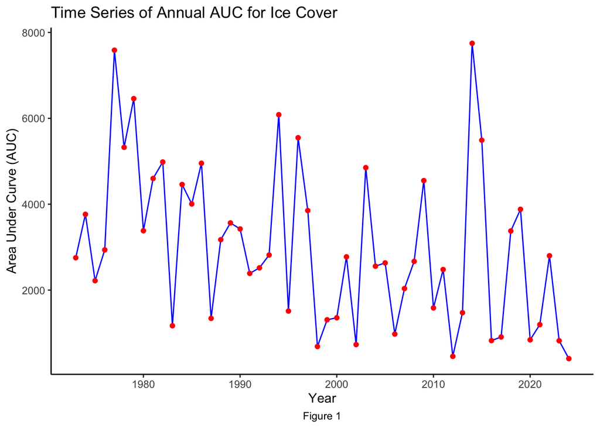

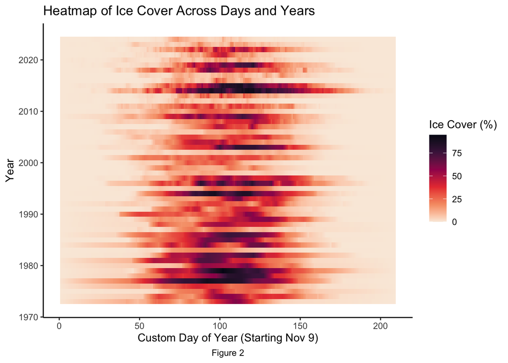

### Results of Analysis

The Area Under the Curve (AUC) is used for examining systemic changes in annual ice cover on the Great Lakes over the past 50 years. AUC provides a comprehensive metric that integrates both the extent and duration of ice cover, capturing year-to-year variability more effectively than single-point measures like mean or maximum ice cover. It aligns with ecological relevance, reflecting the cumulative impact of ice cover changes over time. Additionally, AUC supports robust trend analysis by summarizing annual ice dynamics in a single value, making it suitable for inferential procedures that assess long-term changes in response to climatic shifts. For an initial investigation for trend in AUC, a visualization is produced to determine how the AUC values behave over time (Figure 3).

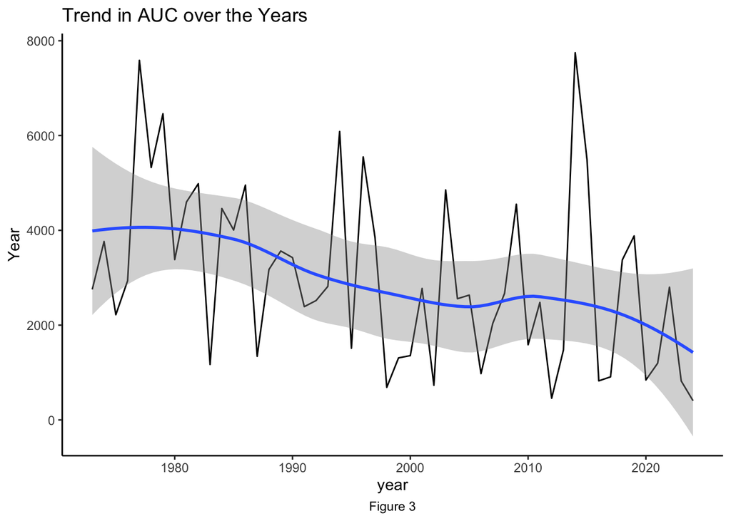

The trend in AUC over the years does not appear strictly linear. Figure 3 shows an initial decline in AUC values from the 1970s to the 1980s, followed by fluctuations with occasional stabilization in mid-years and another decline in recent years. The blue smoothed trend line suggests a non-linear pattern, with distinct phases of decrease and variability. This indicates that the relationship between time and AUC is more complex than a simple linear trend.

Understanding the long-term trends in Great Lakes ice cover requires robust statistical methods that can capture potential non-linear patterns in the data. While simpler models, such as linear regression, can provide an initial insight, they may overlook more complex relationships between time and ice cover. Given the observed variability in the time series, a polynomial model is a natural next step to explore whether trends in the Area Under the Curve (AUC) are linear or exhibit curvature over time. The results from the polynomial is summarized in table 2.

Table 2: Summary of Polynomial Regression Model for AUC

|  | Estimate | Std. Error | t value | P-value |
| --- | --- | --- | --- | --- |
| (Intercept) | 3004.7906 | 242.920 | 12.3694640 | 0.0000000 |
| poly(year, 2)1 | -5071.3514 | 1751.721 | -2.8950675 | 0.0056471 |
| poly(year, 2)2 | 279.4091 | 1751.721 | 0.1595055 | 0.8739263 |

The polynomial regression model indicates a significant relationship between the year and AUC, with an overall model p-value of 0.02066. The linear component (poly(year,2)1) is statistically significant (p = 0.00565), suggesting a declining trend in ice cover over time. However, the quadratic component (poly(year,2)2) is not significant (p = 0.87393), implying that the trend is primarily linear rather than strongly non-linear. The model explains approximately 14.6% of the variance in AUC ($R^2 = 0.1464$), reflecting the inherent complexity of the data. These results highlight a significant decline in perecent ice cover, aligning with the hypothesis of systemic changes over the years.

The diagnostic checks for the polynomial model indicate that most assumptions are reasonably satisfied. The independence of residuals was confirmed through the Durbin-Watson test, showing no significant autocorrelation. Homoscedasticity was verified, with residuals displaying constant variance as supported by the Breusch-Pagan test. Linearity was also upheld, as residuals versus fitted values showed no systematic patterns. However, the normality assumption appears slightly violated, as suggested by deviations in the Q-Q plot and the Shapiro-Wilk test. While normality violations may not severely impact the model’s validity due to the robustness of regression methods, it should be noted in the interpretation of results.

#### Mann-Kendall Test

The Mann-Kendall trend test is a non-parametric statistical method used to detect the presence of a monotonic trend in time series data. It is particularly important in this scenario as it does not require the data to follow a specific distribution, making it ideal for analyzing long-term changes in annual AUC (Area Under the Curve) values for Great Lakes ice cover. This approach helps determine whether observed changes over the past 50 years represent a statistically significant trend, which is essential for assessing the impacts of climatic changes on ice cover. Table 3 displays the result of the Man-Kendall test.

Table 3: Results of the Mann-Kendall Trend Test

| Statistic | Value |
| --- | --- |
| S | -402.0000000 |
| Var(S) | 16059.3300000 |
| Tau | -0.3031674 |
| Z | -3.1643000 |
| P-value | 0.0015540 |

The Mann-Kendall test results indicate a statistically significant downward trend in AUC values over the past 50 years. The S statistic (-402) suggests a negative trend, meaning annual ice cover has decreased over time. The Kendall’s Tau (-0.303) reflects a moderate negative correlation between year and AUC, further supporting this trend. The Z-statistic (-3.164) and the p-value (0.0015) confirm that the trend is highly significant $( p < 0.05 )$, indicating that the observed decline is unlikely due to random variation. These findings provide robust evidence of a systemic reduction in ice cover on the Great Lakes, potentially linked to climate change.

## References

- NOAA Great Lakes Environmental Research Laboratory. (n.d.). Great Lakes ice data. Retrieved from https://www.glerl.noaa.gov/data/ice/